# My project

I am researching the applications of Genetic Algorithms (GAs) on fully autonomous road networks, specifically, *(theoretical)* autonomous motorways

- Self driving cars are becoming more and more prevelant.
- All currently implemented systems are *selfish*, i.e. each vehicle is only concerned with itself and minimising the travel time of their occupants.
- By taking a higher level view of vehicle routing we can potentially reduce the average travel time, saving more time in total, increasing efficiency of existing road networks.

## Genetic Algorithms

Genetic algorithms are a nature-inspired optimisation technique that mimic the process of evolution on populations of candidate solutions.

Their abstract composition is represented nicely by my code:

```julia
𝓕 = curry(curry(Fitness, road), other_routes) # Curry fitness function with road as this is a static attribute of the function. Allows for nicer piping of data.
P = generatePopulation(n, start, goal, road)
map(p -> p.fitness = p |> 𝓕, P) # Calculate fitness for initial population, map 𝓕 over all Individuals
while n_gens > 0 && length(P) > 0# Replace with stopping criteria
    # savefig(plotGeneration!(draw_road(road,0,20),P,road,100,100-n_gens),string("./gifgen/gen-",100-n_gens))
    P = (P
        |> P -> selection(P, method=selection_method)  # Selection operator
        |> simple_crossover |> new_pop -> append!(P, new_pop)  # Crossover operator & Add newly generated individuals to population
        |> P -> mutation!(P,road,method=mutation_method) # apply mutation operator
        |> P -> begin map(p -> p.fitness = p |> 𝓕, P); P end # recalculate fitness of population after mutation
        |> P -> map(repair, P)  # attempt repair of invalid solutions
        |> P -> sort(P, by=p -> p.fitness) # Sort my fitness
        |> P -> filter(isValid, P) # remove invalid solutions
        |> P -> P[1:minimum([n,length(P)])] # take top n
    )
    n_gens -= 1
end
```

[output not shown]

# Recap: Single agent planning

In my previous demo I showed my working single-agent planner.

It was able to:

- Avoid obstacles of circular and rectangular shape
- Avoid leaving the predefined road-space

```julia
P = GA(
    start_point,
    goal_point,
    road,
    n_gens = 3,
    n = 5,
    selection_method = "roulette",
)
plotGeneration!(road_plt, P)
```

[figure not shown]

Below you can see an example of the learning process over the course of 100 generations for a simliar road space problem

[figure not shown]

# Multi-agent planning

I have since expanded this solution to allow for the planning of multiple agents within the same stretch of road. A key factor of this extension is making sure the routes do not collide.

## Intersections & collisions

How do I differentiate between path intersection (legal) and route collision (illegal)?

I make an assumption that all agents are travelling at the same constant speed.

The routes are defined as Bezier Curves and as such the position along the route at any time $t$ is given by $B(t)$, I can therefore say that if $\exists t. B_1(t) == B_2(t)$ then routes $B_1$ and $B_2$ collide at some time $t$ Solving this equation however, is not trivial and as such the common approach to finding intersections between two Bezier curves is to approximate the answer via recursive subdivision, still a very computationally expensive procedure

At one point this process alone resulted in a $\approx 50\times$ slowdown! To tackle this issue, I parallelised my `bezInt` function so that it can take advantage of the 16 cores in my system.

`collisionDetection` then wraps this result and works out the lengths of the road segments in which the intersection is detected and derives whether they collide.

I also added a number of time-saving heuristics into my intersection detection. These include the logic that if no points in a random sample along a curve lie inside the convex hull of another curve, and vice virsa, they cannot intersect and deeper checking can be skipped. This is seen in the following code:

```julia
ts = rand(0:0.05:1, 1000)
B1_points = map(t -> B1(t), ts)
B2_points = map(t -> B2(t), ts)
hull_intersection =
    length(
        filter(
            each -> each == 1,
            [
                Luxor.isinside(
                    p,
                    B1 |> toRealArray |> convex_hull |> toLuxPoints,
                    allowonedge = true,
                ) for p in
                B2_points |>
                toRealArray |>
                convex_hull |>
                toLuxPoints
            ] ∪ [
                Luxor.isinside(
                    p,
                    B2 |> toRealArray |> convex_hull |> toLuxPoints,
                    allowonedge = true,
                ) for p in
                B1_points |>
                toRealArray |>
                convex_hull |>
                toLuxPoints
            ],
        ),
    ) != 0
```

[output not shown]

Initally, I did not have the random sample. instead checking each point in the convex hulls, However this failed to detect the intersection in the edge case below $\downarrow$

```julia
plt
```

[figure not shown]

This is as although the curves clearly intersect, none of the points in their convex hulls lie in the space defined by the convex hull of the other curve

I also instituted a recursion depth limit, some edge cases will subdivide the curve until each section is infinitesimally small and slow the process down

```julia
starts = [Point(0, 5), Point(0, 8), Point(0, 6)]

goals = [Point(20, 8), Point(18, 3), Point(15, 5)]

n=6 # size of population
ng=2 # number of generations


P = PCGA(
    starts,
    goals,
    road,
    n_gens = ng,
    n = n,
    selection_method = "roulette",
    mutation_method = "gaussian",
)
```

```
3-element Array{Individual,1}:
 Individual(Phenotype(Point(0, 5), Point[Point(0, 5), Point(2.966666666666667, 5.0), Point(8.333333333333332, 5.5), Point(14.299999999999999, 6.0), Point(20, 8)], Point(20, 8)), 20.331149467910464)
 Individual(Phenotype(Point(0, 8), Point[Point(0, 8), Point(11.9, 3), Point(18, 3)], Point(18, 3)), 18.844645651242097)
 Individual(Phenotype(Point(0, 6), Point[Point(0, 6), Point(10.55, 5), Point(15, 5)], Point(15, 5)), 15.040291883567122)
```

```
┌ Info: Saved animation to
│   fn = /home/sam/git-clones/Y4-Diss/code/julia/src/anim1.gif
└ @ Plots /home/sam/.julia/packages/Plots/SjqWU/src/animation.jl:104
```

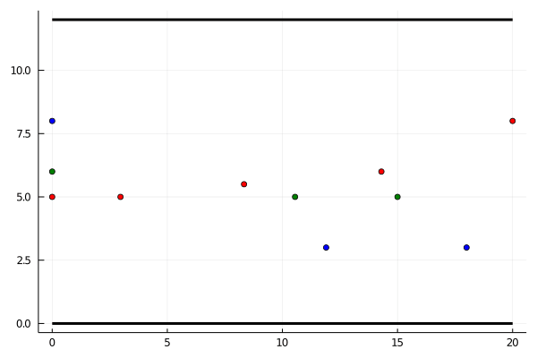

```julia
plot_generation_gif(road,P)
```

# Macro level route planning

Planning routes for vehicles is not just about routing a single set of vehicles through a set section of road. There is a bigger picture: a interconnected network of roads with vehicles traversing multiple different sections of road to get from $A \rightarrow B$

To implement this, I used a graphing library in which I can attach metadata to edges. The metadata I chose to attach was the `Road` structure I have been using for my micro-level planning. I can then perform Dijkstra's algorithm on this road network, weighting each edge with the `Road.length` attribute.

Each agent can then be assigned a series of road segments it must traverse in order to reach it's global goal position.

```julia
desired_paths = [
    (1,4),
    (4,2),
    (1,4),
    (3,5)
]
```

```
4-element Array{Tuple{Int64,Int64},1}:
 (1, 4)
 (4, 2)
 (1, 4)
 (3, 5)
```

```julia
include("demoRoadNetwork.jl")
```

[figure not shown]

```julia
plans = planRoutes(desired_paths, rn);
```

```
macroPath = [1, 3, 2, 5, 4]
macroPath = [4, 5, 2]
macroPath = [1, 3, 2, 5, 4]
macroPath = [3, 2, 5]
```

When planning these routes it is necessary to be aware of which agents are on the same road at the same time.

Just becuase the path for agent $A$ is $1 \rightarrow 2 \rightarrow 3$ and $B$ is $4\rightarrow 2 \rightarrow 3$ doesn't necessarily mean that when planning we must consider both.

However if $len(e12) \leq len(e23)$ then they **will** share the edge $e23$ and the planning must take this into account. Otherwise if $len(e12) > len(e23)$ then agent $B$ will have left the edge before $A$ enters.

Two of these routes should be staggered compared with the other as the *enter* the road later. This has proved difficult to visualise

Edge $e25$ from the graph will have these routes passing through it:

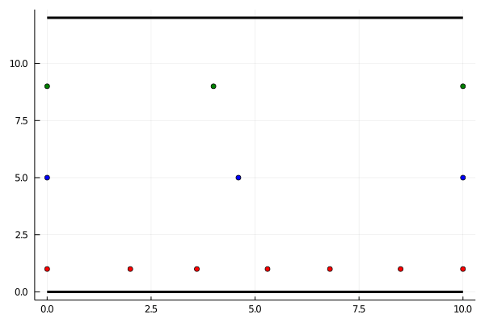

```julia
plts[1]
```

## Edge $e32$

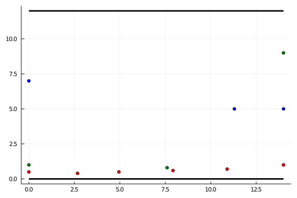

```julia
plts[2]
```

## Edge $e52$

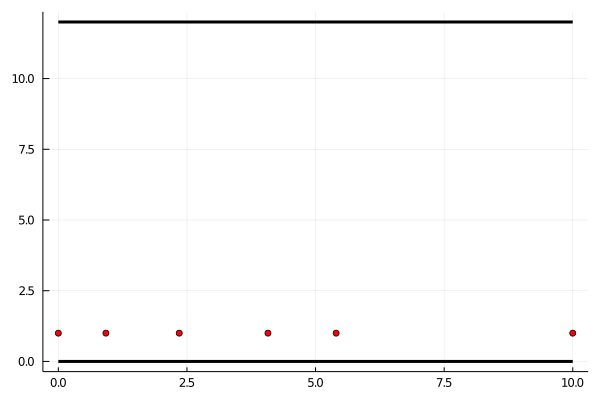

```julia
plts[3]
```

## Edge $e54$

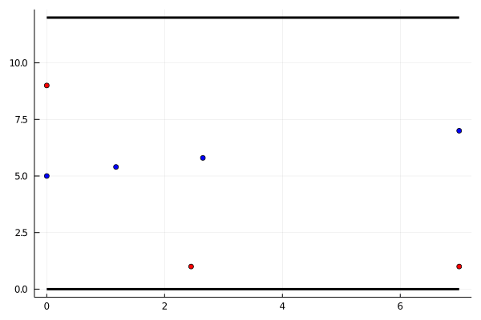

```julia
plts[4]
```

## Edge $e13$

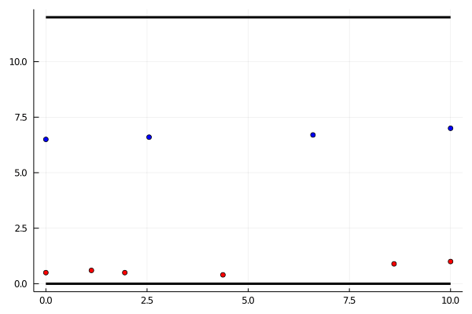

```julia
plts[5]
```

## Edge $e45$

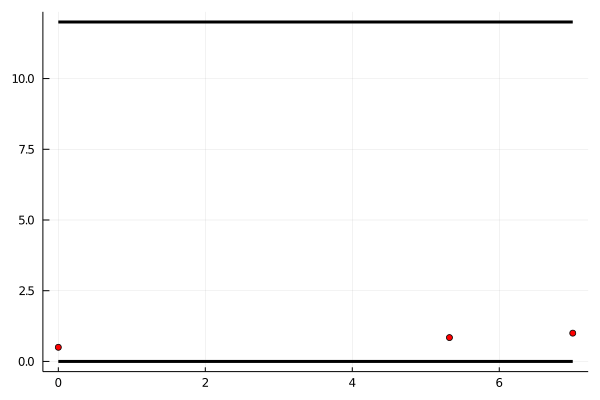

```julia
plts[6]
```